# REMATCH+ Project

Jasin Cekinmez

2024-06-27

### Installs Libraries

```r
#installs libraries
library(DBI)
library(dbplyr)
library(dplyr)
library(duckdb)
library(duckplyr)
library(tidyr)
library(tidyselect)
library(tibble)
library(RSQLite)
library(stringr)
library(rlang)
library(styler)
library(sf)
```

## TibbleCreator() and its setup

#### The goal of TibbleCreator() is to create a table and csv that checks the missingness for the column provided in fullData hence the parameter column. It also can do it on a state or county basis with the region parameter. The year parameter asks whether you want on a yearly basis or overall. FIPS parameter asks whether you want it on FIPS or county. For Column you must provide one of the 103 columns in fullData that matches exactly, for the Region Parameter, you must either put `DEED SITUS STATE - STATIC` for state or `DEED SITUS COUNTY - STATIC` for county, for the YEAR parameter you must input TRUE if you want it on a yearly basis and false if not, likewise for FIPS you need to put in TRUE if you want to do it by FIPS rather than county and False if not. fullDaa, StateYearData, CountyYearData, etc are necessities for TibbleCreator() to work since they are called in it. ALSO** FIPS only works on County since it is on a county basis, the function will still work but have no difference if FIPS was set to False.

```r
#Creates a database connection to cl.db which is the unzipped db file with deeds as the table and is a db file
con = dbConnect(duckdb(),"/projects/SHARKEY/corelogic_pu/CorelogicDeeds/2023Update/cl.db")

#Adds DC to state.abb and the goal of this is to not included territories
statenewabb = c("DC", state.abb)

#Takes the database connection and turns it into a tibble and filters out non states and DC and ones that do not exist
fullData = tbl(con, "deeds")
fullData = fullData |>
  filter(`DEED SITUS STATE - STATIC` %in% statenewabb)


#Filters data to show how many deeds each state has at least listed
StateData = fullData |>
  group_by(`DEED SITUS STATE - STATIC`) |>
  summarize(n = n())

#Filters data to show how many deeds each county has at least listed
CountyData = fullData |>
  filter(`DEED SITUS STATE - STATIC` != "NA") |>
  group_by(`DEED SITUS COUNTY - STATIC`,`DEED SITUS STATE - STATIC`) |>
  summarize(n = n())


#Creates Table filtering deed data for each state and year
StateYearData = fullData |>
  filter(`DEED SITUS STATE - STATIC` != "NA" ) |>
  group_by(substr(`SALE DERIVED DATE`,1,4),`DEED SITUS STATE - STATIC`) |>
  summarize(n=n())



#Creates Table filtering deed data for each county and year
CountyYearData = fullData |>
  filter(`DEED SITUS STATE - STATIC` != "NA" ) |>
  group_by(substr(`SALE DERIVED DATE`,1,4),
           `DEED SITUS COUNTY - STATIC`,
           `DEED SITUS STATE - STATIC`) |>
  summarize(n=n())



# does it by fips rather than county since fips may be more accurate
CountyFipsData=fullData |>
  filter(`DEED SITUS STATE - STATIC` != "NA"& `FIPS CODE`!="NA") |>
  group_by(`DEED SITUS STATE - STATIC`,`FIPS CODE`) |>
  summarize(n = n())


#creates tibble for each column and reports the missingness
#' tibbleCreator() Function
#'
#' @param column refers to the column in Corelogic
#' @param region refers to if you want the string "DEED SITUS COUNTY - STATIC" or "DEED SITUS STATE - STATIC"
#' @param year   You must give a boolean for the parameter true means you want it on a time scale false is no
#' @param fips   You must give a boolean for the parameter true means you want it using FIPS rather than county
#'
#' @return a table with county/state (and year) and the relevant column
#' @export
#'
#' @examples tibbleCreator("SALE AMOUNT","DEED SITUS STATE - STATIC",TRUE) Creates a table with the Sale Amount, with year data per state
tibbleCreator= function(column, region, year, fips) {

#turns column into variable rather than string
column = as.name(column)

#Checks if we want to filter by state data
if(region == "DEED SITUS STATE - STATIC"){

#Filters solely by state not year
  if(!year){

#creates the column name
colu = paste0(toString(column)," PRESENT")

#filters entire data by state and disregards NA values and gives the total number of deeds per state satisfying the condition
region = as.name(region)

#Filters data to only count data that has the relevant column filled checks if you want fips code

data = fullData |>
          group_by(region) |>
          filter(column !="NA") |>
         summarize(!!colu := n())
#the above table is now being appended to the right by the total # of deeds per state

region = toString(region)

#Combines tables
data = left_join(data, StateData, by=region)

#Changes column names
data = data |>
  rename("Total Deeds" = `n`)


#Now gives the missingness
data = data |>
  mutate("% missing"= round((100* (1-(!!sym(colu))/(`Total Deeds`))), digits=2))

#Arranges in descending order
data = data |>
  arrange(desc(`DEED SITUS STATE - STATIC`))


#CREATES CSV File
column = toString(column)
csvtitle=paste0("/home/jc9154/cl-validation/Output/",column,region,".csv")
write.csv(data,csvtitle)
return(data)}

#Filters by state and year
  else{

colu = paste0(toString(column)," PRESENT")

#filters entire data by state and disregards NA values and gives the total number of deeds per state satisfying the condition
region = as.name(region)

data = fullData |>
  filter(column!="NA") |>
  filter(`DEED SITUS STATE - STATIC` != "NA") |>
  group_by(substr(`SALE DERIVED DATE`, 1, 4),`DEED SITUS STATE - STATIC`) |>
  summarize(!!colu := n())

region = toString(region)

data = left_join(data, StateYearData, by=c("substr(`SALE DERIVED DATE`, 1, 4)","DEED SITUS STATE - STATIC"))

data = data |>
  rename("Total Deeds" = `n`)

data = data |>
  rename(`SALE DERIVED YEAR` = `substr(\`SALE DERIVED DATE\`, 1, 4)`)

data = data |>
  mutate("% missing"= round((100* (1-(!!sym(colu))/(`Total Deeds`))), digits=2))

#Now gives the missingness
data = data |>
  arrange(desc(`DEED SITUS STATE - STATIC`),desc(`SALE DERIVED YEAR`))

#CREATES CSV File
column=toString(column)
csvtitle=paste0("/home/jc9154/cl-validation/Output/",column,region,"YEAR.csv")
write.csv(data,csvtitle)


return(data) }}

#Filters by county data
else{

  if(!year){

region = as.name(region)

colu = paste0(toString(column)," PRESENT")

if(!fips){
data = fullData |>
  filter(column != "NA") |>
  filter(`DEED SITUS STATE - STATIC` != "NA" ) |>
  group_by(region,`DEED SITUS STATE - STATIC`)  |>
  summarize(!!colu := n())

region = toString(region)

data = data|>
  left_join(CountyData, data, by=c(region,"DEED SITUS STATE - STATIC"))


data = data |>
  rename("Total Deeds" = `n`)


data = data |>
  mutate("% missing"= round((100* (1-(!!sym(colu))/(`Total Deeds`))), digits=2))

#Now gives the missingness
data = data |>
  arrange(desc(`DEED SITUS STATE - STATIC`),desc(`DEED SITUS COUNTY - STATIC`))

#CREATES CSV File
column=toString(column)
csvtitle=paste0("/home/jc9154/cl-validation/Output/",column,region,".csv")
write.csv(data,csvtitle)


return(data)
}
else {
data = fullData |>
  filter(column != "NA"& `FIPS CODE`!="NA") |>
  filter(`DEED SITUS STATE - STATIC` != "NA" ) |>
  group_by(`DEED SITUS STATE - STATIC`,`FIPS CODE`) |>
  summarize(!!colu := n())



data = data|>
  left_join(CountyFipsData, data, by=c("DEED SITUS STATE - STATIC","FIPS CODE"))


data = data |>
  rename("Total Deeds" = `n`)


data = data |>
  mutate("% missing"= round((100* (1-(!!sym(colu))/(`Total Deeds`))), digits=2))

#Now gives the missingness
data = data |>
  arrange(desc(`DEED SITUS STATE - STATIC`))

#CREATES CSV File
column=toString(column)
csvtitle=paste0("/home/jc9154/cl-validation/Output/",column,region,".csv")
write.csv(data,csvtitle)


return(data)
}}

#Filters by county and year
  else{

colu = paste0(toString(column)," PRESENT")
#filters entire data by state and disregards NA values and gives the total number of deeds per state satisfying the condition

region = as.name(region)

data = fullData |>
  filter(column!="NA") |>
  filter(`DEED SITUS STATE - STATIC` != "NA") |>
  group_by(substr(`SALE DERIVED DATE`, 1, 4),
           `DEED SITUS COUNTY - STATIC`,
           `DEED SITUS STATE - STATIC`) |>
  summarize(!!colu := n())


region = toString(region)

data = left_join(data,CountyYearData, by=c("substr(`SALE DERIVED DATE`, 1, 4)","DEED SITUS COUNTY - STATIC","DEED SITUS STATE - STATIC"))

data = data |>
  rename("Total Deeds" = `n`)

data = data |>
  rename(`SALE DERIVED YEAR` = `substr(\`SALE DERIVED DATE\`, 1, 4)`)

data = data |>
  mutate("% missing"= round((100* (1-(!!sym(colu))/(`Total Deeds`))), digits=2))


data = data |>
  arrange(desc(`DEED SITUS STATE - STATIC`),
          desc(`DEED SITUS COUNTY - STATIC`) ,
          desc(`SALE DERIVED YEAR`))

#CREATES CSV File
column=toString(column)
csvtitle=paste0("/home/jc9154/cl-validation/Output/",column,region,"YEAR.csv")
write.csv(data,csvtitle)


return(data)


}}}

#CREATES CSV's in Output Folder
#Well now tibbleCreator needs a fourth parameter

#data=tibbleCreator("ACTUAL YEAR BUILT - STATIC","DEED SITUS STATE - STATIC",FALSE)
#data=tibbleCreator("BUYER OCCUPANCY CODE","DEED SITUS STATE - STATIC",FALSE)
#data=tibbleCreator("CLIP","DEED SITUS STATE - STATIC",FALSE)
#data=tibbleCreator("DEED CATEGORY TYPE CODE","DEED SITUS STATE - STATIC",FALSE)
#data=tibbleCreator("SALE DOCUMENT TYPE  CODE","DEED SITUS STATE - STATIC",FALSE)
#data=tibbleCreator("FIPS CODE","DEED SITUS STATE - STATIC",FALSE)
#data=tibbleCreator("PRIMARY CATEGORY CODE","DEED SITUS STATE - STATIC",FALSE)
#data=tibbleCreator("PROPERTY INDICATOR CODE - STATIC","DEED SITUS STATE - STATIC",FALSE)
#data=tibbleCreator("SALE AMOUNT","DEED SITUS STATE - STATIC",FALSE)
#data=tibbleCreator("SALE DERIVED DATE","DEED SITUS STATE - STATIC",FALSE)
#data=tibbleCreator("SALE DERIVED RECORDING DATE","DEED SITUS STATE - STATIC",FALSE)
#data=tibbleCreator("DEED SITUS CITY - STATIC","DEED SITUS STATE - STATIC",FALSE)
#data=tibbleCreator("DEED SITUS ZIP CODE - STATIC","DEED SITUS STATE - STATIC",FALSE)
#data=tibbleCreator("EFFECTIVE YEAR BUILT - STATIC","DEED SITUS STATE - STATIC",FALSE)
#data=tibbleCreator("FIPS CODE","DEED SITUS COUNTY - STATIC",FALSE)
#disconnects in order to avoid garbage collecting
dbDisconnect(con)
```

### Alongside some other visualization, this code made me realize that the Corelogic Dataset has not updated county names, as in 1997 Dade County became Miami Dade County, but this dataset still uses Dade County even after 1997.

```r
con = dbConnect(duckdb(),"/projects/SHARKEY/corelogic_pu/CorelogicDeeds/2023Update/cl.db")

fullData = tbl(con, "deeds")
fullData = fullData |>
  filter(`DEED SITUS STATE - STATIC` %in% statenewabb)

Miami=fullData |> filter(`DEED SITUS CITY - STATIC`=="MIAMI") |> filter(as.numeric(`ACTUAL YEAR BUILT - STATIC`)>1997) |> select(`DEED SITUS COUNTY - STATIC`)
print(Miami)
```

```
## # Source:   SQL [?? x 1]
## # Database: DuckDB v0.10.2 [jc9154@Linux 4.18.0-553.5.1.el8_10.x86_64:R 4.4.0//projects/SHARKEY/corelogic_pu/CorelogicDeeds/2023Update/cl.db]
##    `DEED SITUS COUNTY - STATIC`
##    <chr>
##  1 DADE
##  2 DADE
##  3 DADE
##  4 DADE
##  5 DADE
##  6 DADE
##  7 DADE
##  8 DADE
##  9 DADE
## 10 DADE
## # ℹ more rows
```

```r
dbDisconnect(con)
```

### This code snippet shows that there are errors in the reporting of States whether numerical or ones that simply just don’t exist

```r
con = dbConnect(duckdb(),"/projects/SHARKEY/corelogic_pu/CorelogicDeeds/2023Update/cl.db")

fullData = tbl(con, "deeds")
#Takes out lowercase state abbreviations made me realize there are quite a bit of different non state abbreviations
#,yet there are still many typo caps
caps= fullData |> filter(str_detect(`DEED SITUS STATE - STATIC`,"[A-Z][A-Z]")||is.na(`DEED SITUS STATE - STATIC`)) |>        group_by(`DEED SITUS STATE - STATIC`) |>
  summarize(n = n())
print(caps)
```

```
## # Source:   SQL [?? x 2]
## # Database: DuckDB v0.10.2 [jc9154@Linux 4.18.0-553.5.1.el8_10.x86_64:R 4.4.0//projects/SHARKEY/corelogic_pu/CorelogicDeeds/2023Update/cl.db]
##    `DEED SITUS STATE - STATIC`        n
##    <chr>                          <dbl>
##  1 <NA>                        33174468
##  2 TX                          29105600
##  3 FL                          43571883
##  4 VT                            904631
##  5 WV                           2938992
##  6 VI                             23894
##  7 AR                           5618020
##  8 AK                            630706
##  9 NU                                 1
## 10 SL                                 1
## # ℹ more rows
```

```r
dbDisconnect(con)
```

### Deals with FMV Sales (Talk with Angela about next steps)

```r
con = dbConnect(duckdb(),"/projects/SHARKEY/corelogic_pu/CorelogicDeeds/2023Update/cl.db")

fullData = tbl(con, "deeds")
fullData = fullData |>
  filter(`DEED SITUS STATE - STATIC` %in% statenewabb)


#displays number of NON FMV data
FMVData= fullData |> filter(`PRIMARY CATEGORY CODE`=="B"||`PRIMARY CATEGORY CODE`=="C"||`FORECLOSURE REO SALE INDICATOR`=="1"||`SALE TYPE CODE`=="L"||`INTERFAMILY RELATED INDICATOR`=="1"||`SHORT SALE INDICATOR`=="1")|>
  summarize(n=n())
#print(FMVData)

#Currently FMV DATA took a while to realize that the reason sale type code was causing issues was that it had NA Values
#
FMVData = fullData |>
  filter(`PRIMARY CATEGORY CODE`!="B"&`PRIMARY CATEGORY CODE`!="C"&`FORECLOSURE REO SALE INDICATOR`!="1"& `INTERFAMILY RELATED INDICATOR`!="1" & `SHORT SALE INDICATOR`!="1") |>
  filter(`SALE TYPE CODE`!="L"||is.na(`SALE TYPE CODE`))
#print(FMVData)


#THIS SECTION looks at each group to see the most common type of each and which codes exist
Primtype= fullData |> group_by(`PRIMARY CATEGORY CODE`) |>
summarize(n=n())
#print(Primtype)

Cattype= fullData |> group_by(`DEED CATEGORY TYPE CODE`) |> summarize(n=n())
#print(Cattype)

SaleType= fullData |> group_by(`SALE TYPE CODE`) |> summarize(n=n())
#print(SaleType)

Saledoc = fullData |> group_by(`SALE DOCUMENT TYPE  CODE`) |> summarize(n=n())
#print(Saledoc)

family= fullData |> group_by(`INTERFAMILY RELATED INDICATOR`) |> summarize(n=n())
#print(family)

short= fullData |> group_by(`SHORT SALE INDICATOR`) |> summarize(n=n())
#print(short)

foreclosure = fullData |> group_by(`FORECLOSURE REO SALE INDICATOR`) |> summarize(n=n())
#print(foreclosure)

dbDisconnect(con)
```

#### Quantile Data Info

```r
con = dbConnect(duckdb(),"/projects/SHARKEY/corelogic_pu/CorelogicDeeds/2023Update/cl.db")

fullData = tbl(con, "deeds")
fullData = fullData |>
  filter(`DEED SITUS STATE - STATIC` %in% statenewabb)

##### THIS FINDS THE MEDIAN SALE DERIVED DATE YEAR FOR EACH STATE
QuartileData=fullData |> filter(`DEED SITUS STATE - STATIC`!="NA") |> select(`SALE DERIVED DATE`,`DEED SITUS STATE - STATIC`) |> mutate("SALE DERIVED YEAR"=substr(`SALE DERIVED DATE`,1,4)) |> group_by(`DEED SITUS STATE - STATIC`) |> select(-`SALE DERIVED DATE`) |> summarize(Median = median(as.numeric(`SALE DERIVED YEAR`),na.rm = TRUE ))


#finds the 2.5% quantile for each state
QuantileStateData = fullData |>
  filter(`DEED SITUS STATE - STATIC`!="NA") |>
  select(`SALE DERIVED DATE`,`DEED SITUS STATE - STATIC`) |>
  mutate("SALE DERIVED YEAR"=substr(`SALE DERIVED DATE`,1,4)) |>
  group_by(`DEED SITUS STATE - STATIC`) |>
  summarize(quantile2.5Year = quantile(as.numeric(`SALE DERIVED YEAR`), na.rm = T, probs = c(.025)))

csvtitle=paste0("/home/jc9154/cl-validation/Output/","QuantileStateData")
#write.csv(QuantileStateData,csvtitle)

QuantileArmsStateData= fullData |> filter(`DEED SITUS STATE - STATIC`!="NA"&`PRIMARY CATEGORY CODE`=="A") |>
  select(`SALE DERIVED DATE`,`DEED SITUS STATE - STATIC`) |>
  mutate("SALE DERIVED YEAR"=substr(`SALE DERIVED DATE`,1,4)) |>
  group_by(`DEED SITUS STATE - STATIC`) |>
  summarize(quantile2.5Year = quantile(as.numeric(`SALE DERIVED YEAR`), na.rm = T, probs = c(.025)))


csvtitle=paste0("/home/jc9154/cl-validation/Output/","QuantileArmsStateData")
#write.csv(QuantileArmsStateData,csvtitle)

#finds the 2.5% Quantile for each county
QuantileCountyData = fullData |>
  filter(`DEED SITUS STATE - STATIC`!="NA") |>
  select(`SALE DERIVED DATE`,
         `DEED SITUS COUNTY - STATIC` ,
         `DEED SITUS STATE - STATIC`) |>
  mutate("SALE DERIVED YEAR"=substr(`SALE DERIVED DATE`,1,4)) |>
  group_by(`DEED SITUS COUNTY - STATIC`,`DEED SITUS STATE - STATIC`) |>
  summarize(quantile2.5Year = quantile(as.numeric(`SALE DERIVED YEAR`), na.rm = T, probs = c(.025)))


#UNCOMMENT WHEN NECESSARY
QuantileArmsCountyData=fullData |>
  filter(`DEED SITUS STATE - STATIC`!="NA"&`PRIMARY CATEGORY CODE`=="A") |>
 select(`SALE DERIVED DATE`,
         `DEED SITUS COUNTY - STATIC` ,
         `DEED SITUS STATE - STATIC`) |>
  mutate("SALE DERIVED YEAR"=substr(`SALE DERIVED DATE`,1,4)) |>
 filter(as.numeric(`SALE DERIVED YEAR`)>1970) |>
  group_by(`DEED SITUS COUNTY - STATIC`,`DEED SITUS STATE - STATIC`) |>
  summarize(quantile2.5Year = quantile(as.numeric(`SALE DERIVED YEAR`), na.rm = T, probs = c(.025)))
csvtitle=paste0("/home/jc9154/cl-validation/Output/","QuantileArmsCountyData")
#write.csv(QuantileArmsCountyData,csvtitle)

dbDisconnect(con)
```

### Just to illustrate some errors in the Deeds Data we can see how mistaken the data is in San Diego

```r
con = dbConnect(duckdb(),"/projects/SHARKEY/corelogic_pu/CorelogicDeeds/2023Update/cl.db")

fullData = tbl(con, "deeds")
fullData = fullData |>
  filter(`DEED SITUS STATE - STATIC` %in% statenewabb)

# this code helped me realize mistakes present in the data
#filters data to show how many deeds each state has at least listed
CountyData= fullData|>filter(`DEED SITUS STATE - STATIC`!="NA")|> filter(`DEED SITUS COUNTY - STATIC`=="SAN DIEGO" & `DEED SITUS STATE - STATIC` != "CA") |> select(`DEED SITUS CITY - STATIC`,`DEED SITUS COUNTY - STATIC`,`DEED SITUS STATE - STATIC`,`FIPS CODE`)
print(CountyData)
```

```
## # Source:   SQL [?? x 4]
## # Database: DuckDB v0.10.2 [jc9154@Linux 4.18.0-553.5.1.el8_10.x86_64:R 4.4.0//projects/SHARKEY/corelogic_pu/CorelogicDeeds/2023Update/cl.db]
##    `DEED SITUS CITY - STATIC` DEED SITUS COUNTY - STATI…¹ DEED SITUS STATE - S…²
##    <chr>                      <chr>                       <chr>
##  1 DENVER                     SAN DIEGO                   CO
##  2 PORTLAND                   SAN DIEGO                   OR
##  3 MALVERN                    SAN DIEGO                   PA
##  4 MESA                       SAN DIEGO                   AZ
##  5 FOUR OAKS                  SAN DIEGO                   NC
##  6 YUMA                       SAN DIEGO                   AZ
##  7 PHOENIX                    SAN DIEGO                   AZ
##  8 HENDERSON                  SAN DIEGO                   NV
##  9 NORTH CANTON               SAN DIEGO                   OH
## 10 BOSSIER CITY               SAN DIEGO                   LA
## # ℹ more rows
## # ℹ abbreviated names: ¹`DEED SITUS COUNTY - STATIC`,
## #   ²`DEED SITUS STATE - STATIC`
## # ℹ 1 more variable: `FIPS CODE` <chr>
```

```r
dbDisconnect(con)
```

### Takes a closer look at Arms Length Sales

```r
con = dbConnect(duckdb(),"/projects/SHARKEY/corelogic_pu/CorelogicDeeds/2023Update/cl.db")

fullData = tbl(con, "deeds")
fullData = fullData |>
  filter(`DEED SITUS STATE - STATIC` %in% statenewabb)


CountyFipsTypeAData=fullData |>
 filter(`DEED SITUS STATE - STATIC` != "NA"& `FIPS CODE`!="NA"&`PRIMARY CATEGORY CODE`=="A") |>
  group_by(`DEED SITUS STATE - STATIC`,`FIPS CODE`) |>
  summarize(n = n())
#print(CountyFipsTypeAData)

data = fullData |>
  filter(`FIPS CODE`!="NA"&`PRIMARY CATEGORY CODE`=="A"&`SALE AMOUNT`!="NA") |>
 filter(`DEED SITUS STATE - STATIC` != "NA" ) |>
 group_by(`DEED SITUS STATE - STATIC`,`FIPS CODE`) |>
  summarize("Sale Amount Present" := n())



data = data|>
  left_join(CountyFipsTypeAData, data, by=c("DEED SITUS STATE - STATIC","FIPS CODE"))


data = data |>
  rename("Total Deeds" = `n`)


data = data |>
  mutate("% missing"= round((100* (1-(`Sale Amount Present`)/(`Total Deeds`))), digits=2))

#Now gives the missingness
data = data |>
 arrange(desc(`DEED SITUS STATE - STATIC`))

#print(data)

#CREATES CSV File
#csvtitle=paste0("/home/jc9154/cl-validation/Output/","SaleAmountTypeA",".csv")
#write.csv(data,csvtitle)

dbDisconnect(con)
```

### Looks at when the Fips is missing and its effect on the missingness of the Street, Zipcode, and City

```r
con = dbConnect(duckdb(),"/projects/SHARKEY/corelogic_pu/CorelogicDeeds/2023Update/cl.db")

fullData = tbl(con, "deeds")
fullData = fullData |>
  filter(`DEED SITUS STATE - STATIC` %in% statenewabb)


missingFips=fullData |> filter(is.na(`FIPS CODE`)) |> mutate("CITY PRESENT"=is.na(`DEED SITUS CITY - STATIC`), .before = CLIP) |> mutate("ZIPCODE PRESENT"=is.na(`DEED SITUS ZIP CODE - STATIC`), .before = CLIP) |> mutate("County Present"=is.na(`DEED SITUS COUNTY - STATIC`), .before = CLIP) |> mutate("State Present"= is.na(`DEED SITUS STATE - STATIC`), .before = CLIP) |> mutate("Street Present"=is.na(`DEED SITUS STREET NAME - STATIC`), .before = CLIP) |> filter(`Street Present`==TRUE & `CITY PRESENT`==TRUE & `ZIPCODE PRESENT` == TRUE)


#I got the two tables in the doc by simply adding or removing ! from Street NOT Present
missingFipsProp=fullData |> filter(is.na(`FIPS CODE`)) |> mutate("CITY NOT PRESENT"=is.na(`DEED SITUS CITY - STATIC`), .before = CLIP) |> mutate("ZIPCODE NOT PRESENT"=is.na(`DEED SITUS ZIP CODE - STATIC`), .before = CLIP) |> mutate("Street NOT Present"=is.na(`DEED SITUS STREET NAME - STATIC`), .before = CLIP) |> filter(!(`Street NOT Present`)) |> group_by(`Street NOT Present`,`CITY NOT PRESENT`,`ZIPCODE NOT PRESENT`) |> summarise(n=(n()), .groups = "drop") |> mutate(prop=round((n/sum(n)),digits = 3))

missingFips = missingFips |> filter(is.na(`APN SEQUENCE NUMBER`)==FALSE) |> summarise(n=n())


dbDisconnect(con)
```

```r
con = dbConnect(duckdb(),"/projects/SHARKEY/corelogic_pu/CorelogicDeeds/2023Update/cl.db")

fullData = tbl(con, "deeds")
fullData = fullData |>
  filter(`DEED SITUS STATE - STATIC` %in% statenewabb)

kodzebue=fullData |> filter(`DEED SITUS CITY - STATIC`=="KOTZEBUE") |> select(`FIPS CODE`,`DEED SITUS CITY - STATIC`,`DEED SITUS COUNTY - STATIC`)
print(kodzebue)
```

```
## # Source:   SQL [2 x 3]
## # Database: DuckDB v0.10.2 [jc9154@Linux 4.18.0-553.5.1.el8_10.x86_64:R 4.4.0//projects/SHARKEY/corelogic_pu/CorelogicDeeds/2023Update/cl.db]
##   `FIPS CODE` `DEED SITUS CITY - STATIC` `DEED SITUS COUNTY - STATIC`
##   <chr>       <chr>                      <chr>
## 1 <NA>        KOTZEBUE                   KENAI
## 2 35053       KOTZEBUE                   SOCORRO
```

```r
dbDisconnect(con)
```

## LollipopCreator()

#### This function creates a Lollipop graph so for the parameter column you give a column in the database which is the parameter column and then give the column number for which you want to start at and end is the column you want to end at. So the LollipopCreator() makes a lollipop graph comparing the missigness for the specific columns you chose given when the column paramter you gave is present and not present.

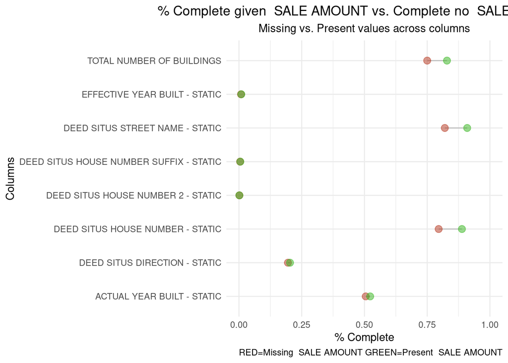

```r
library(ggplot2)
con = dbConnect(duckdb(),"/projects/SHARKEY/corelogic_pu/CorelogicDeeds/2023Update/cl.db")

fullData = tbl(con, "deeds")
fullData = fullData |>
  filter(`DEED SITUS STATE - STATIC` %in% statenewabb)

LollipopCreator= function(column,start,end){
ColumnNameList = colnames(fullData)[start:end]
  missing = numeric(length(ColumnNameList))
  nonmissing = numeric(length(ColumnNameList))

column = as.name(column)
MissingColumn=fullData |> filter(is.na(column))
PresentColumn=fullData |> filter(!is.na(column))
MissingColumnValue=fullData |> filter(is.na(column)) |> summarise(n=n()) |> pull(n)
PresentColumnValue=fullData |> filter(!is.na(column)) |> summarise(n=n()) |> pull(n)
for(i in 1:length(ColumnNameList)){

ValuePresentNonColumn= MissingColumn |> filter(!is.na(.data[[ColumnNameList[i]]])) |> summarise(n=n())|> pull(n)
ValuePresentColumn=PresentColumn |> filter(!is.na(.data[[ColumnNameList[i]]])) |> summarise(n=n())|> pull(n)

ValueNonColumn=ValuePresentNonColumn/MissingColumnValue
ValueColumn=ValuePresentColumn/PresentColumnValue

missing[i]=ValueNonColumn
nonmissing[i]=ValueColumn
}
LollipopData=data.frame(MissingSomething=missing, PresentColumn=nonmissing)
row.names(LollipopData)=ColumnNameList

 ggplot(LollipopData) +
    geom_segment(aes(x = ColumnNameList, xend = ColumnNameList, y = MissingSomething, yend = PresentColumn), color = "grey") +
    geom_point(aes(x = ColumnNameList, y = MissingSomething), color = rgb(0.7, 0.2, 0.1, 0.5), size = 3) +
    geom_point(aes(x = ColumnNameList, y = PresentColumn), color = rgb(0.2, 0.7, 0.1, 0.5), size = 3) +
    coord_flip() +
    labs(
      x = "Columns",
      y = "% Complete",
      title = paste("% Complete given ", column, "vs. Complete no ", column),
      subtitle = "Missing vs. Present values across columns", caption = paste("RED=Missing ",column, "GREEN=Present ",column)
    ) +
    ylim(0, 1) +
    theme_minimal() +
    theme(
      legend.position = "right",  # Adjust legend position as needed
      plot.title = element_text(hjust = 0.5),  # Center the title
      plot.subtitle = element_text(hjust = 0.5)  # Center the subtitle
    )}

LollipopCreator("SALE AMOUNT",16,23)
```

```r
#disconnects in order to avoid garbage collecting
dbDisconnect(con)
```